# Describing Distributions ▶ Quantitative Data

Updated: Wednesday, February 13, 2019 @ 02:18:09 PM

## What is EDA?

"If we need a short suggestion of what exploratory data analysis is, I would suggest that

- It is an attitude AND
- A flexibility AND
- Some graph paper (or transparencies, or both).""

~ John Tukey, 1980

Tukey also advocated for development of computerized tools to facilitate EDA, so people could focus on interpreting results.

## How We Describe Distributions

**Categorical Variables**

- frequency / relative frequency

*Summaries based on counting how many times categories occur.*

**Quantitative Variables**

- shape
- center
- spread
- outliers

*Shape, center, and spread characterize the pattern of numerical observations. Outliers are deviations from the pattern.*

## Shape

- how many modes?
  - unimodal
  - bimodal
  - multimodal
- symmetric or skewed?
  - right skewed
  - left skewed
- skewness (quantification of asymmetry)
- kurtosis (conformation of peak and tails)

We rely heavily on plots to assess shape. Summary measures like skewness and kurtosis should be interpeted *with* plots.

## Plots for Assessing Shape

- histogram
  - [geom_histogram()](https://ggplot2.tidyverse.org/reference/geom_histogram.html)
- density plot
  - [geom_density()](https://ggplot2.tidyverse.org/reference/geom_density.html)
- empirical cumulative distribution plot
  - [stat_ecdf()](https://ggplot2.tidyverse.org/reference/stat_ecdf.html)
- boxplot
  - [geom_boxplot()](https://ggplot2.tidyverse.org/reference/geom_boxplot.html)

See AsULearn Statistics Terms & Concepts glossary and course textbooks for more information on plots and summaries.

## Some Data to Plot

Load gasmileage.csv and oldfaithful.csv into RStudio. Let's plot!

```r
library(dplyr)
glimpse(mileage)
```

```
Observations: 100
Variables: 1
$ mpg <dbl> 36.3, 41.0, 36.9, 37.1, 44.9, 36.8, 30.0, 37.2, 42.1, 36.7, …
```

```r
glimpse(geyser)
```

```
Observations: 272
Variables: 2
$ erupt_time <dbl> 3.600, 1.800, 3.333, 2.283, 4.533, 2.883, 4.700, 3.60…
$ wait_time  <int> 79, 54, 74, 62, 85, 55, 88, 85, 51, 85, 54, 84, 78, 4…
```

## Basic Histogram

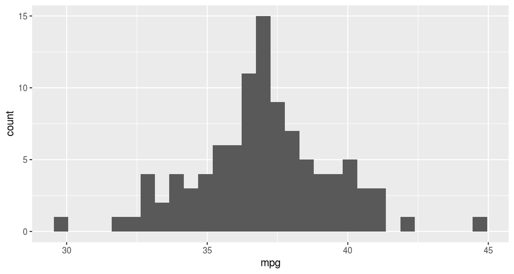

```r
library(ggplot2)
ggplot(mileage, aes(x = mpg)) + geom_histogram()
```

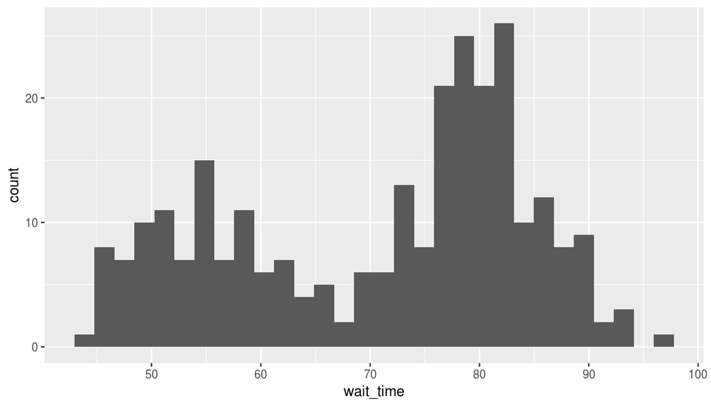

```r
ggplot(geyser, aes(x = wait_time)) + geom_histogram()
```

## Rules of Thumb for Number of Bins

- between 5 and 15 bins
- between 5 and 20 bins
- number of bins near the square root of the sample size n
- Sturge’s rule, number of bins around 1 + 3.322 × log(n)
- Freedman-Diaconis rule, about 2 × IQR × n^(−1/3) bins

Finding the right binwidth is an interative process. You can set an approximate number of bins, a specific bin width, or exact boundaries you want for the bins.

The default number of bins is 30.

https://ggplot2.tidyverse.org/reference/geom_histogram.html

## Basic Density

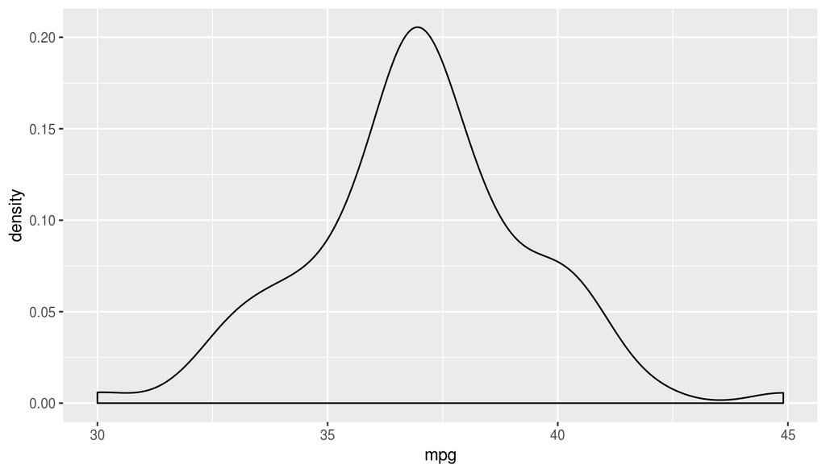

```r
ggplot(mileage, aes(x = mpg)) + geom_density()
```

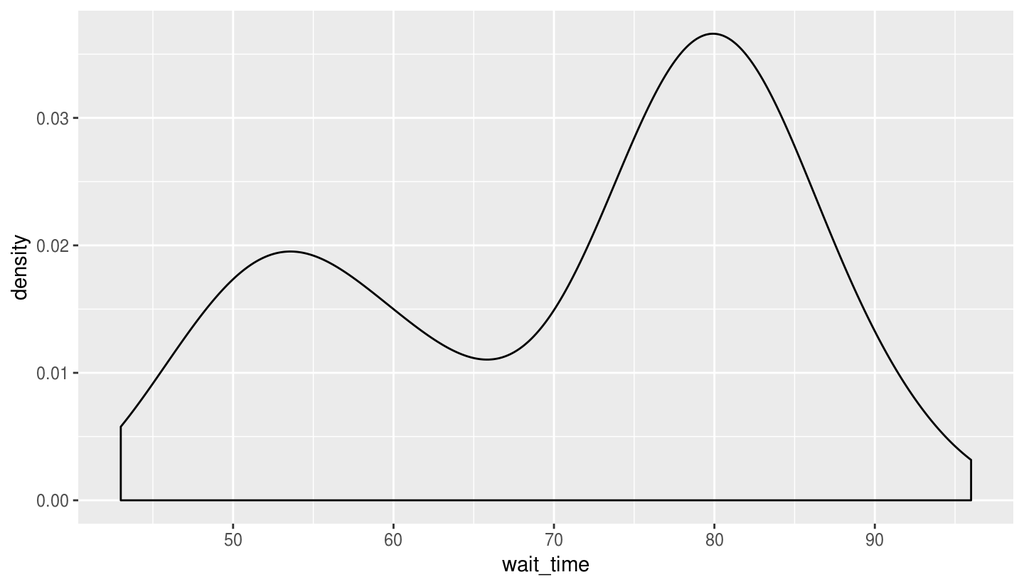

```r
ggplot(geyser, aes(x = wait_time)) + geom_density()
```

## Density Over Histogram

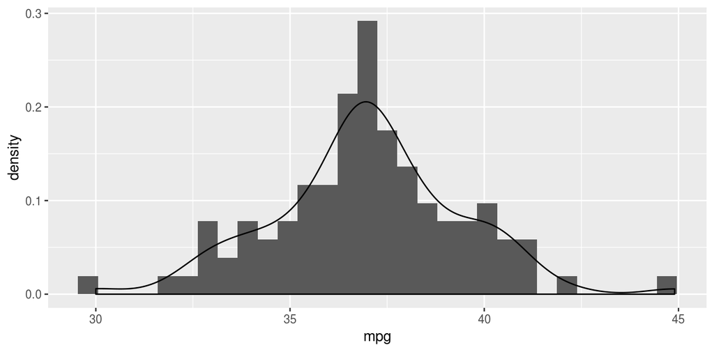

```r
ggplot(mileage, aes(x = mpg)) +
  geom_histogram(aes(y=..density..)) +
  geom_density()
```

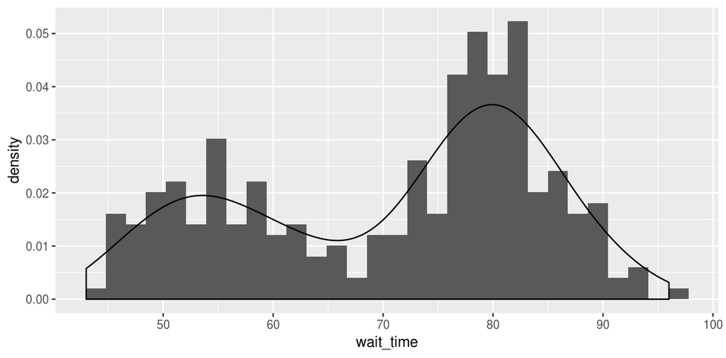

```r
ggplot(geyser, aes(x = wait_time)) +
  geom_histogram(aes(y=..density..)) +
  geom_density()
```

## Add Some Color

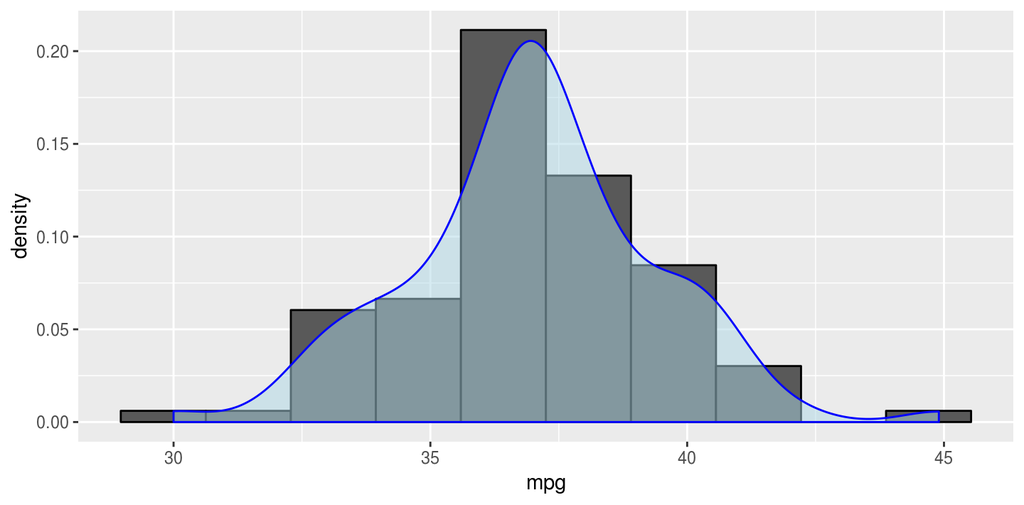

```r
ggplot(mileage, aes(x = mpg)) +
  geom_histogram(aes(y=..density..), bins = 10, color = "black") +
  geom_density(fill = "lightblue", color = "blue", alpha = 0.50)
```

## Empirical Cumulative Distribution

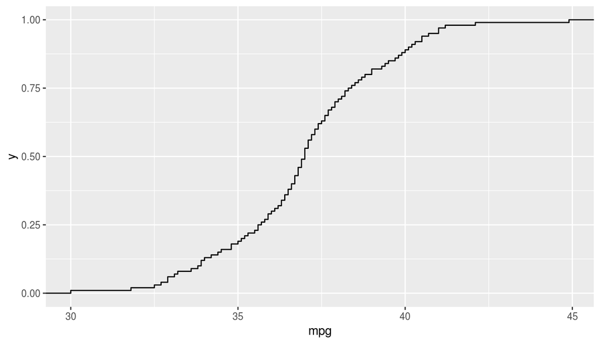

```r
ggplot(mileage, aes(x = mpg)) + stat_ecdf()
```

## Density and ECDF

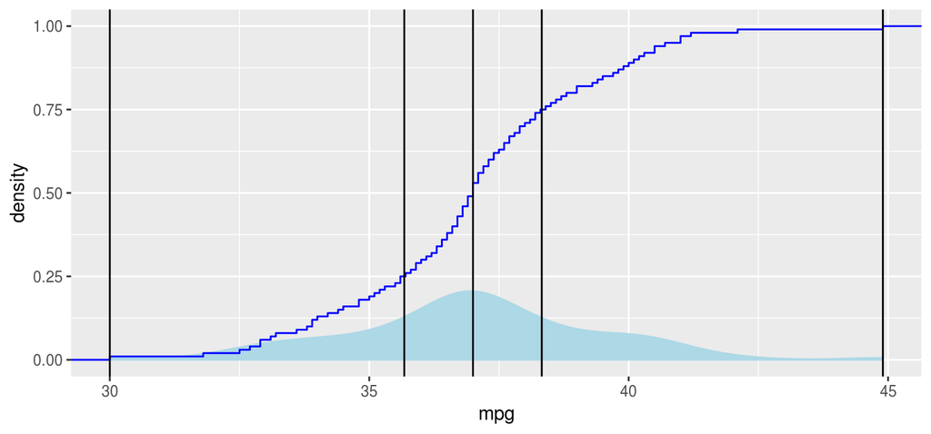

```r
ggplot(mileage, aes(x = mpg)) +
  geom_density(color = "lightblue", fill = "lightblue") +
  stat_ecdf(color = "blue") +
  geom_vline(xintercept = quantile(mileage$mpg), c(.25, .50, .75))
```

## Skewness and Kurtosis

```r
library(moments)
skewness(mileage$mpg)
```

```
[1] 0.05014194
```

```r
kurtosis(mileage$mpg)
```

```
[1] 3.672556
```

```r
kurtosis(mileage$mpg) - 3
```

```
[1] 0.6725558
```

We will discuss more about connections between measures in upcoming slides.

## Center

- mean
  - arithmetic mean ("average", *expected value*)
  - geometric mean
  - weighted mean
  - trimmed mean
- median
- mode (we use this more with reference to shape)

Mean and median are both the "middle" of a given distribution, but the two summaries define middle or *center* differently.

## Spread

- variance
  - population
  - sample
- standard deviation
- mean absolute deviation (mad)
- median absolute deviation (*also* mad?)
- interquartile range (IQR)
- range

Summarizing the deviations of a set of values from some center point is a common technique in statistics.

## Measures Based on Moments

In physics, a moment of force is the turning effect of the force about a central point, as a function of distance from the point. Statistical moments are a similar idea.

mean (first moment)

- the mean \(\mu\) is the value that makes \(\Sigma(X - \mu)^1 = 0\) true
- mean is the center of mass or *balance point* of a distribution

variance (second moment)

\[M_2 = \frac{\Sigma(X - \mu)^2}{n} = \sigma^2\]

\[\text{standard deviation} = \sigma \]

skewness (third moment)

\[M_3 = \frac{\Sigma(X - \mu)^3}{n}\]

\[skewness = \frac{\Sigma(X - \mu)^3}{\sigma^3}\]

kurtosis (fourth moment)

\[M_4 = \frac{\Sigma(X - \mu)^4}{n}\]

\[kurtosis = \frac{\Sigma(X - \mu)^4}{\sigma^4}\]

## Moment-Based Summaries in R

- `mean()`
- `var()`
- `sd()`
- `skewness()`
- `kurtosis()`
- `mad()` (not a moment, but a related concept)

As seen on an earlier slide, `skewness` and `kurtosis` come from the `moments` package. For each function, you should explore the syntax, parameters, and output.

## Measures Based on Ordered Counts

- five-number-summary
  - minimum
  - first quartile (Q<sub>1</sub>)
  - median
  - third quartile (Q<sub>3</sub>)
  - maximum
- interquartile range (IQR)
- range
- percentiles / quantiles

## Count-Based Summaries in R

- `fivenum()`
- `min()`
- `median()`
- `max()`
- `IQR()`
- `range()`
- `quantile()`

Again, you should explore the syntax, parameters, and output of each function to understand how it works.

## Summarizing Using `dplyr`

```r
mileage %>% summarize(n     = n(),
                      xbar  = mean(mpg, na.rm = TRUE),
                      stdev = sd(mpg, na.rm = TRUE),
                      min   = fivenum(mpg)[1],
                      Q1    = fivenum(mpg)[2],
                      med   = fivenum(mpg)[3],
                      Q3    = fivenum(mpg)[4],
                      max   = fivenum(mpg)[5],
                      skew  = skewness(mpg, na.rm = TRUE),
                      kurt  = kurtosis(mpg, na.rm = TRUE))
```

```
    n   xbar    stdev min    Q1 med    Q3  max       skew     kurt
1 100 36.994 2.417897  30 35.65  37 38.35 44.9 0.05014194 3.672556
```

Use `group_by()` before `summarize()` if you want summaries for separate subgroups in your dataset.

## Boxplots and Outliers

One of the most common rules for determining outliers is based on the five-number summary. We can visualize the five-number summary and outliers in a boxplot.

[figure not shown]

## Calculating the Fences

```r
lowerFence <- fivenum(mileage$mpg)[2] - 1.5 * IQR(mileage$mpg)
lowerFence
```

```
[1] 31.675
```

```r
upperFence <- fivenum(mileage$mpg)[4] + 1.5 * IQR(mileage$mpg)
upperFence
```

```
[1] 42.325
```

```r
boxplot.stats(sort(mileage$mpg))$out
```

```
[1] 30.0 44.9
```

## Calculating the Fences in `dplyr`

```r
mileage %>%
  summarize(lower_fence = fivenum(mpg)[2] - 1.5 * IQR(mpg),
            upper_fence = fivenum(mpg)[4] + 1.5 * IQR(mpg))
```

```
  lower_fence upper_fence
1      31.675      42.325
```

Use `group_by()` before `summarize()` if you want the fences for separate subgroups in your dataset.

You can also `filter()` the dataset for cases containing outliers using the fences, rather than simply using `boxplot.stats()` to print outlier values. Why might this be more beneficial?

## Boxplot for One Variable

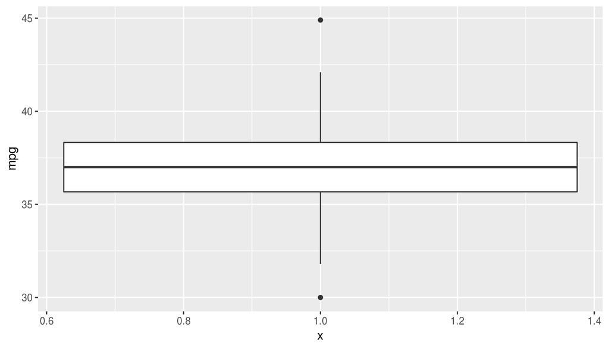

```r
ggplot(mileage, aes(x = 1, y = mpg)) + geom_boxplot()
```

## Comparing Groups

Load the FlightDelays.csv dataset into RStudio. Let's compare!

```r
glimpse(flt_del)
```

```
Observations: 4,029
Variables: 10
$ ID           <int> 1, 2, 3, 4, 5, 6, 7, 8, 9, 10, 11, 12, 13, 14, 15, …
$ Carrier      <fct> UA, UA, UA, UA, UA, UA, UA, UA, UA, UA, UA, UA, UA,…
$ FlightNo     <int> 403, 405, 409, 511, 667, 669, 673, 677, 679, 681, 6…
$ Destination  <fct> DEN, DEN, DEN, ORD, ORD, ORD, ORD, ORD, ORD, ORD, O…
$ DepartTime   <fct> 4-8am, 8-Noon, 4-8pm, 8-Noon, 4-8am, 4-8am, 8-Noon,…
$ Day          <fct> Fri, Fri, Fri, Fri, Fri, Fri, Fri, Fri, Fri, Fri, F…
$ Month        <fct> May, May, May, May, May, May, May, May, May, May, M…
$ FlightLength <int> 281, 277, 279, 158, 143, 150, 158, 160, 160, 163, 1…
$ Delay        <int> -1, 102, 4, -2, -3, 0, -5, 0, 10, 60, 0, 32, 0, 44,…
$ Delayed30    <fct> No, Yes, No, No, No, No, No, No, No, Yes, No, Yes, …
```

## Comparative Boxplots

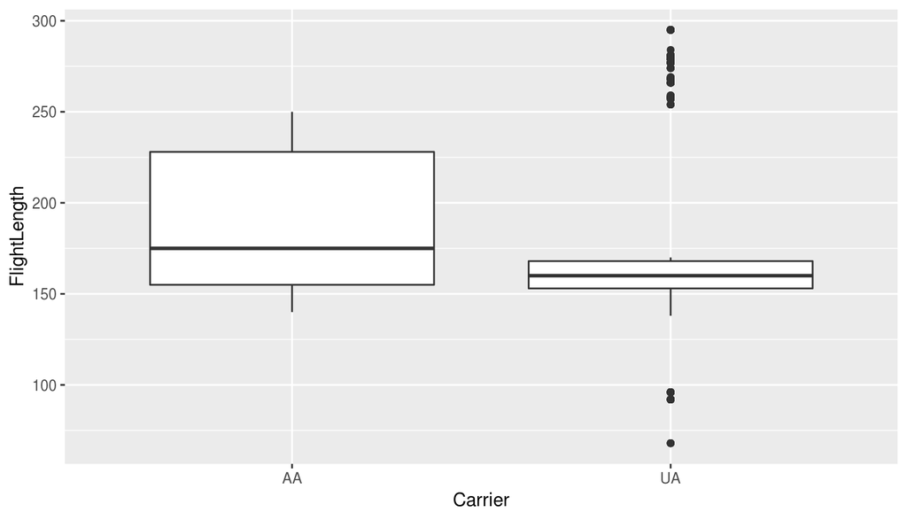

```r
ggplot(flt_del, aes(x = Carrier, y = FlightLength)) + geom_boxplot()
```